# Worked solutions to exercises on simulation of stochastic dynamic models

Aaron King, Carles Bretó and Edward Ionides

[Licensed under the Creative Commons Attribution-NonCommercial license](http://creativecommons.org/licenses/by-nc/4.0/). Please share and remix noncommercially, mentioning its origin.

## Exercise: Little o notation

We combine $f(x+\delta)=f(x)+ \delta\,g(x) + o(\delta)$, the definition that $h(\delta)=o(\delta)$ means $\lim_{\delta\to 0} \frac{h(\delta)}{\delta} = 0$. Thus, we get
$$\lim_{\delta\to 0} \frac{f(x+\delta)-f(x)}{\delta} = g(x)$$
which matches the definition that $df(x)/dx = g(x)$.

Little o notation is compact, and so is useful for simplifying complex expressions. The downside is that we have to put in the work to convert it to limit statements if we want to check that the math is formally correct.

## Exercise: Euler versus Gillespie

For reasons explained in the lesson, we may not be critically worried about whether a numerical simulation method gives an exact solution to the systems defining a continuous time equation. The Gillespie algorithm gives an exact solution (if rates are constant) at the expense of additional computation time. We may on occastion want an exact simulator, and in that case Gillespie can be used.

## Exercise: Explore the SIR model

In the simulated outbreaks, the overall incidence is much too low, and the outbreak dies out after only a few weeks. To attempt to simulate data for which the observed data is a more plausible realization, we might try increasing the force of infection.

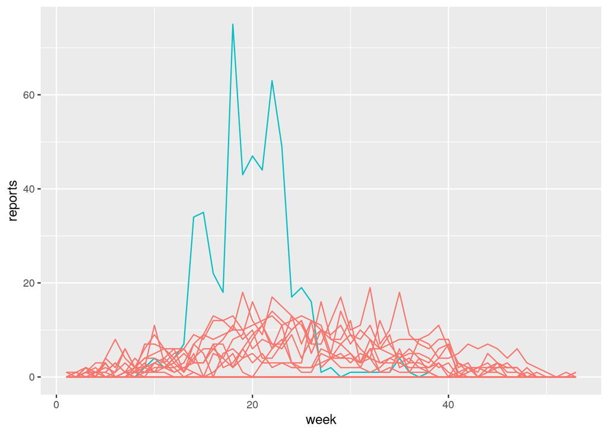

```r
measSIR %>%
  simulate(params=c(Beta=20,mu_IR=0.5,rho=0.5,eta=0.03,N=38000),
    nsim=20,format="data.frame",include.data=TRUE) %>%
  ggplot(aes(x=week,y=reports,group=.id,color=.id=="data"))+
  geom_line()+
  guides(color=FALSE)
```

Taking it farther....

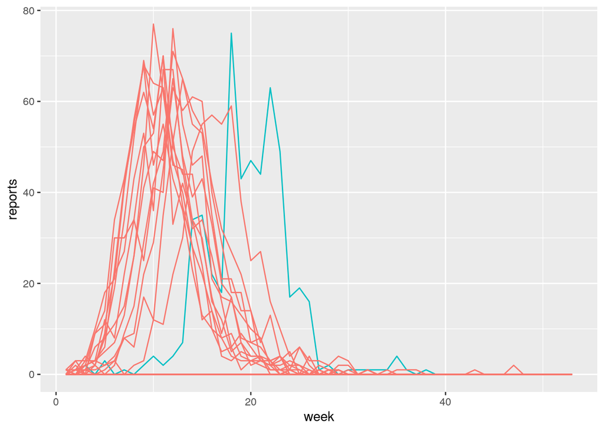

```r
measSIR %>%
  simulate(params=c(Beta=40,mu_IR=0.5,rho=0.5,eta=0.03,N=38000),
    nsim=20,format="data.frame",include.data=TRUE) %>%
  ggplot(aes(x=week,y=reports,group=.id,color=.id=="data"))+
  geom_line()+
  guides(color=FALSE)
```

While this increases the overall incidence, the epidemic is now peaking too quickly. To counteract this, we might try reducing the recovery rate.

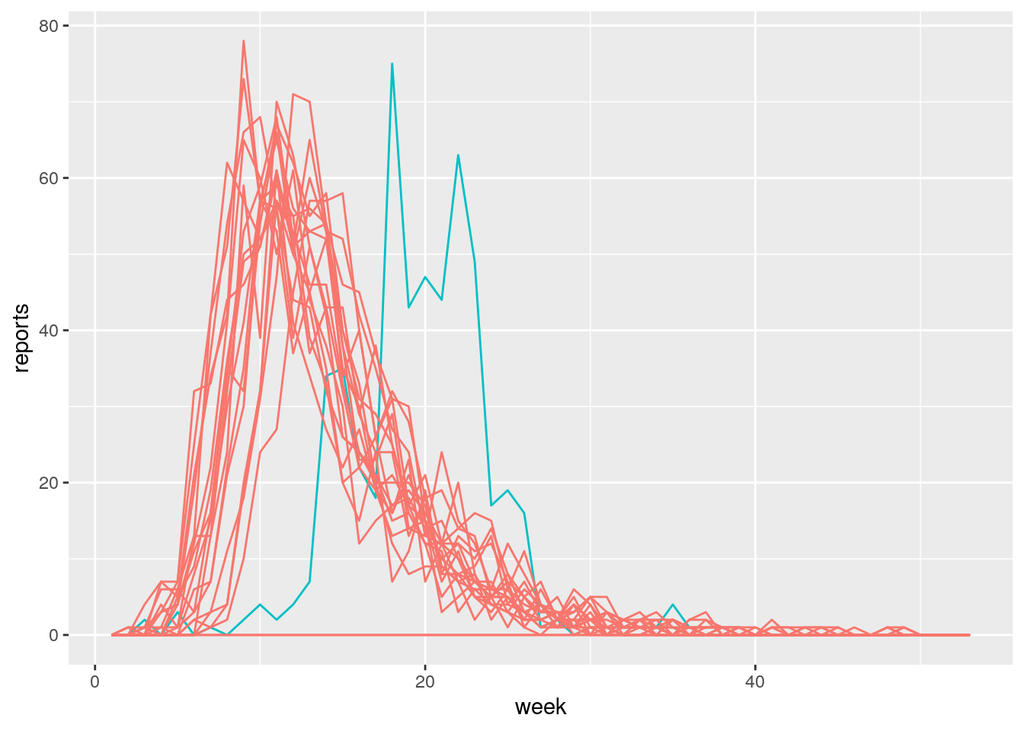

```r
measSIR %>%
  simulate(params=c(Beta=40,mu_IR=0.2,rho=0.5,eta=0.03,N=38000),
    nsim=20,format="data.frame",include.data=TRUE) %>%
  ggplot(aes(x=week,y=reports,group=.id,color=.id=="data"))+
  geom_line()+
  guides(color=FALSE)
```

Additionally, we might have a look at the effects of changing the initial susceptible fraction, $\eta$. It's possible to get something not too awful to contemplate by just manipulating $\eta$, in fact:

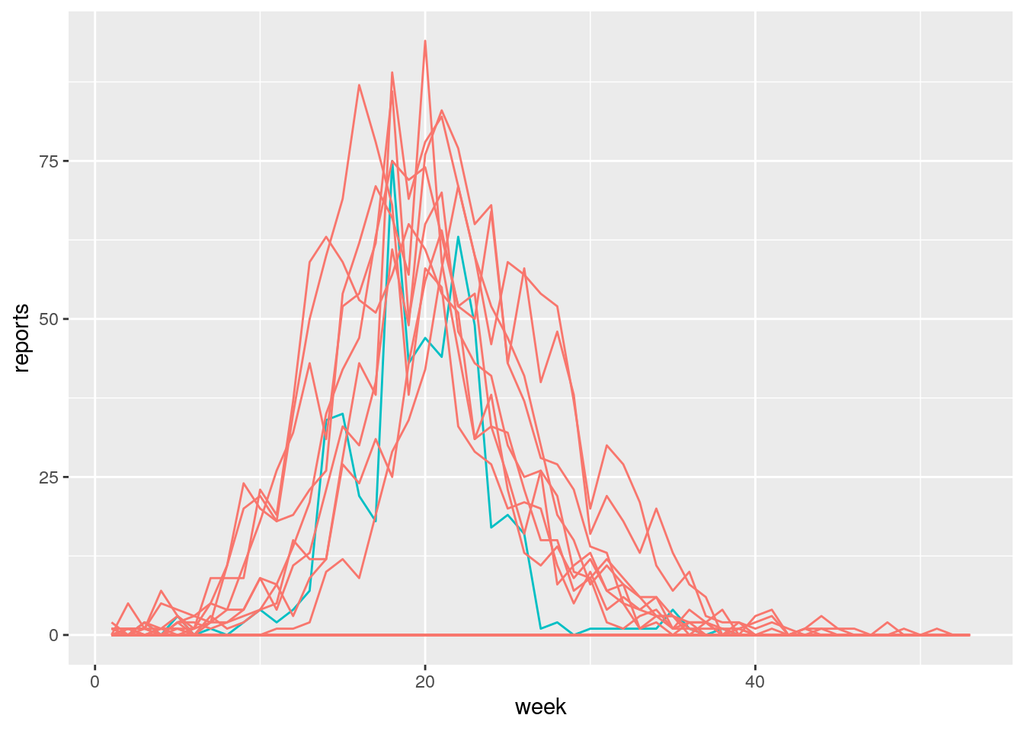

```r
measSIR %>%
  simulate(params=c(Beta=15,mu_IR=0.5,rho=0.5,eta=0.06,N=38000),
    nsim=20,format="data.frame",include.data=TRUE) %>%
  ggplot(aes(x=week,y=reports,group=.id,color=.id=="data"))+
  geom_line()+
  guides(color=FALSE)
```

## Pro-tip

**When using** Rstudio**, turn off automatic save and restore of global workspace.** By default, when you quit a session, **R** asks whether to save the global session to a hidden file, `.RData`, in the current working directory. Presumably because this behavior is annoying, **Rstudio**, by default, answers the "Do you want to save to `.RData`?" question for you, in the affirmative. Also by default, and with only an easily overlooked message in the startup banner, **R** loads such a file, re-establishing the workspace at the start of a session. Because the file is hidden, and the behavior is easy to forget about, this can lead to errors that are difficult to track down. [For example, situations where different results are obtained on different machines during a large parallel computation, despite all the code being precisely the same!] For these reasons, it's best to put a stop to all of this skulduggery.

To do so, go to the "Tools" menu in **Rstudio** and select "Global Options". Make sure the "Restore .RData into workspace at startup" box is unticked. For good measure, set the "Save workspace to .RData on exit" to "Never".

If you ever do want to save your workspace, it's as easy as `save.image(file="<filename>.rda")`; restoring the file is a matter of `load("<filename>.rda")`. When you do this, the file you create will be visible, as of course it should be since you gain nothing by hiding things from yourself!

## Exercise: The SEIR model

The existing code may be modified as follows:

```r
seir_step <- Csnippet("
  double dN_SE = rbinom(S,1-exp(-Beta*I/N*dt));
  double dN_EI = rbinom(E,1-exp(-mu_EI*dt));
  double dN_IR = rbinom(I,1-exp(-mu_IR*dt));
  S -= dN_SE;
  E += dN_SE - dN_EI;
  I += dN_EI - dN_IR;
  R += dN_IR;
  H += dN_IR;
")


seir_init <- Csnippet("
  S = nearbyint(eta*N);
  E = 0;
  I = 1;
  R = nearbyint((1-eta)*N);
  H = 0;
")

measSIR %>%
  pomp(
    rprocess=euler(seir_step,delta.t=1/7),
    rinit=seir_init,
    paramnames=c("N","Beta","mu_EI","mu_IR","rho","eta"),
    statenames=c("S","E","I","R","H")
  ) -> measSEIR
```

Using the rough estimate that the latent period in measles is 8--10da, we take $\mu_{EI}\sim 0.8$wk<sup>-1</sup> and $\mu_{IR}\sim 1.3$wk<sup>-1</sup> (so as to have roughly the same generation time as before).

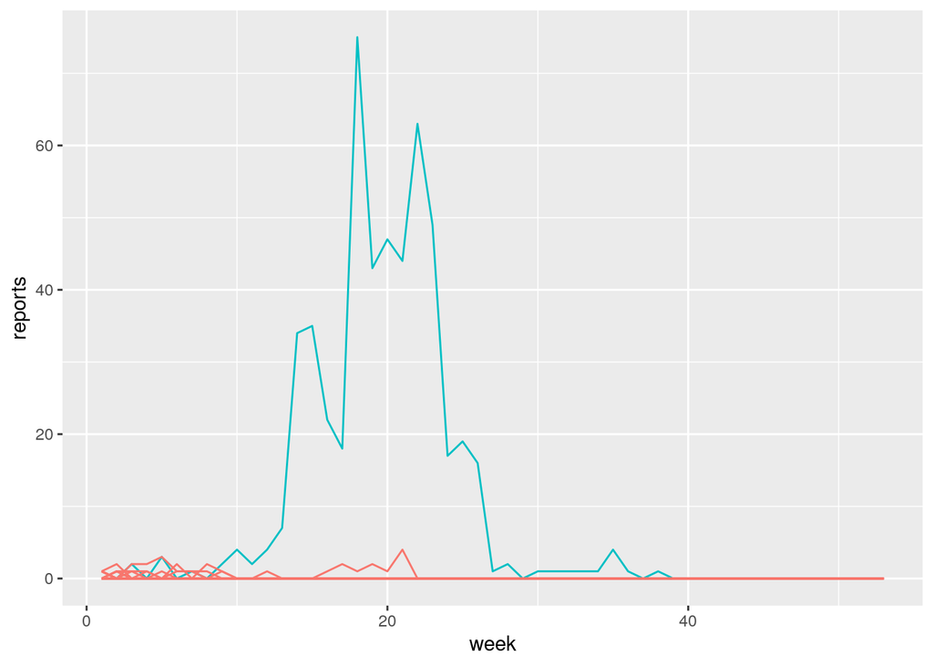

```r
measSEIR %>%
  simulate(params=c(Beta=15,mu_EI=0.8,mu_IR=1.3,rho=0.5,eta=0.06,N=38000),
    nsim=20,format="data.frame",include.data=TRUE) %>%
  ggplot(aes(x=week,y=reports,group=.id,color=.id=="data"))+
  geom_line()+
  guides(color=FALSE)
```

Again one can increase the force of infection:

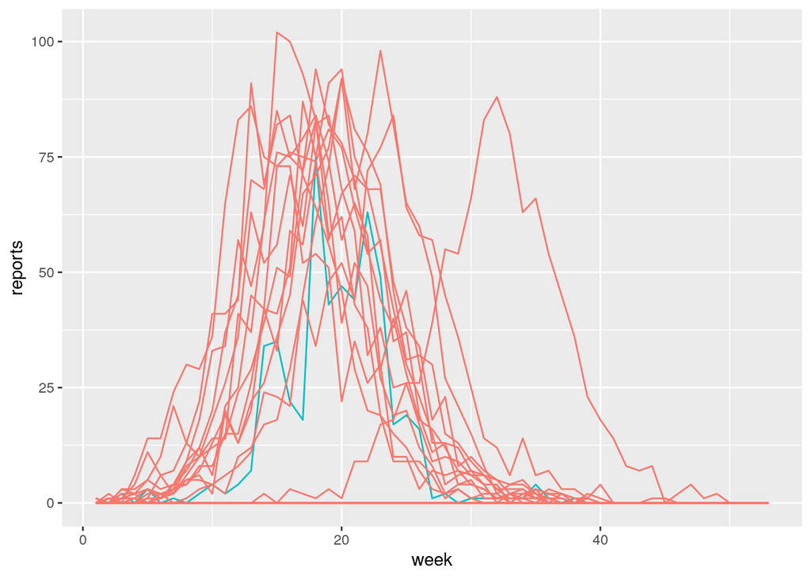

```r
measSEIR %>%
  simulate(params=c(Beta=40,mu_EI=0.8,mu_IR=1.3,rho=0.5,eta=0.06,N=38000),
  nsim=20,format="data.frame",include.data=TRUE) %>%
  ggplot(aes(x=week,y=reports,group=.id,color=.id=="data"))+
  geom_line()+
  guides(color=FALSE)
```

**Back to the course home page**  
**Back to Stochastic Simulation lesson**  
[**R** codes for this document](http://raw.githubusercontent.com/kingaa/sbied/master/stochsim/exercises.R)